# Part I, INTRODUCTION TO DATA ANALYSIS WITH R

Markus Loecher, Berlin School of Economics and Law

# 1 Day 1: Basic R programming

## 1.1 Data Types

#### 1.1.0.1 vectors, matrices, strings, factors

We need to be very clear on the different **data types** in R!

**numbers**:

```r
x = 2
y = 3
x+y
```

```
## [1] 5
```

**vectors**:

```r
x = c(1,2,3)
y = 10:12
#or
y = seq(10,12,by=1)
#operations on x
x[2]
```

```
## [1] 2
```

```r
x[-2]
```

```
## [1] 1 3
```

```r
2*x
```

```
## [1] 2 4 6
```

```r
x^2
```

```
## [1] 1 4 9
```

```r
#built-in functions
mean(x)
```

```
## [1] 2
```

```r
sum(x)
```

```
## [1] 6
```

```r
#vectorized operations
x+y
```

```
## [1] 11 13 15
```

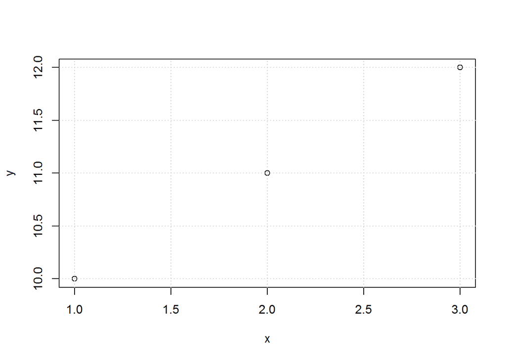

```r
#bare bones graphics
plot(x,y); grid()
```

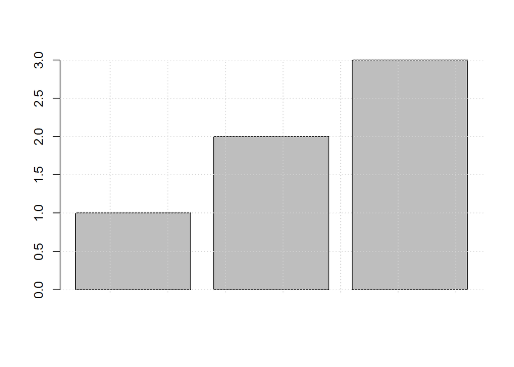

```r
barplot(x); grid()
```

**matrices**:

```r
x = matrix(1:9, ncol=3)
colnames(x) = c("var1","var2","var3")
x
```

```
##      var1 var2 var3
## [1,]    1    4    7
## [2,]    2    5    8
## [3,]    3    6    9
```

```r
dim(x)
```

```
## [1] 3 3
```

```r
x[2,3]
```

```
## var3
##    8
```

```r
x[2,"var1"]
```

```
## var1
##    2
```

```r
colMeans(x)
```

```
## var1 var2 var3
##    2    5    8
```

**data frames**:

```r
x = data.frame(a = 1:3, l = LETTERS[1:3], r = runif(3))
x
```

```
##   a l         r
## 1 1 A 0.8331572
## 2 2 B 0.2068714
## 3 3 C 0.4077474
```

```r
x$l
```

```
## [1] A B C
## Levels: A B C
```

**lists**:

```r
y = list(x = matrix(1:9, ncol=3), l = LETTERS[1:3], r = NA)
y
```

```
## $x
##      [,1] [,2] [,3]
## [1,]    1    4    7
## [2,]    2    5    8
## [3,]    3    6    9
##
## $l
## [1] "A" "B" "C"
##
## $r
## [1] NA
```

**strings**:

```r
x = "chevrolet"
class(x)
```

```
## [1] "character"
```

### 1.1.1 factors in R

Try class(“chevrolet”)

In the Auto set take a look at the data class of the name column:

```r
library(ISLR)
data(Auto)

class(Auto$name)
```

```
## [1] "factor"
```

Try

as.numeric(“chevrolet”)

Try

as.numeric(head(Auto$name))

Look at the help file for read.csv and look for the argument *stringsAsFactors*

You can force a variable to be a factor:

```r
Auto$cylinders = as.factor(Auto$cylinders)
```

#### 1.1.1.1 Understanding factors is extremely important for modeling ! (=dummy variables)

**dates/times**:

```r
x = Sys.Date()
#or
as.Date("2017-03-20")
```

```
## [1] "2017-03-20"
```

```r
y = Sys.time()
x
```

```
## [1] "2018-05-17"
```

```r
y
```

```
## [1] "2018-05-17 11:59:23 CEST"
```

```r
class(x)
```

```
## [1] "Date"
```

```r
class(y)
```

```
## [1] "POSIXct" "POSIXt"
```

```r
as.numeric(x)
```

```
## [1] 17668
```

```r
as.numeric(y)
```

```
## [1] 1526551163
```

```r
#or
unclass(x)
```

```
## [1] 17668
```

```r
unclass(y)
```

```
## [1] 1526551163
```

Let us look at some real data now. We load in the *S&P Stock Market Data* dataset from the *ISLR* library:

```r
library(ISLR)
data(Smarket)

head(Smarket)
```

```
##   Year   Lag1   Lag2   Lag3   Lag4   Lag5 Volume  Today Direction
## 1 2001  0.381 -0.192 -2.624 -1.055  5.010 1.1913  0.959        Up
## 2 2001  0.959  0.381 -0.192 -2.624 -1.055 1.2965  1.032        Up
## 3 2001  1.032  0.959  0.381 -0.192 -2.624 1.4112 -0.623      Down
## 4 2001 -0.623  1.032  0.959  0.381 -0.192 1.2760  0.614        Up
## 5 2001  0.614 -0.623  1.032  0.959  0.381 1.2057  0.213        Up
## 6 2001  0.213  0.614 -0.623  1.032  0.959 1.3491  1.392        Up
```

```r
mean(Smarket$Lag1)
```

```
## [1] 0.0038344
```

- **Year** The year that the observation was recorded
- **Lagi**: Percentage return for i days previous
- **Volume**: Volume of shares traded (number of daily shares traded in billions)
- **Today**: Percentage return for today
- **Direction**: A factor with levels Down and Up indicating whether the market had a positive or negative return on a given day

This is a data frame with **mixed data types**:

```r
dim(Smarket)
```

```
## [1] 1250    9
```

```r
class(Smarket)
```

```
## [1] "data.frame"
```

```r
class(Smarket$Lag1)
```

```
## [1] "numeric"
```

Let us add a proper date variable:

```r
Smarket$day = as.Date("2001-01-01") + 1:1250
```

## 1.2 control structures (for, if else, while)

In a non-vectorized language the above command would have necessitated a loop! Since they are useful on their own in R, we will reproduce the *day* column:

```r
#initialize
Smarket$day = NA

for (i in 1:1250) Smarket$day[i] = as.Date("2001-01-01") + i

#or with multiple statements
for (i in 1:1250) {
  Smarket$day[i] = as.Date("2001-01-01") + i
  if (Smarket$day[i] == "2001-07-04") cat("The return on July 4th was ", Smarket$Today[i], "\n")
}
```

### 1.2.1 Wait a second, shouldn’t we exclude weekends and holidays?

Can we download those from Yahoo finance?

```r
library(tseries)
 # sp500 = get.hist.quote(instrument = "^gspc", "2001-01-02", "2005-12-30",
 #                 quote = c("Open", "Volume"))
 #  save(sp500, file="sp500.rda")
load("data/sp500.rda")
n=nrow(sp500)
#can we compute percent returns?
sp500$Today = round(100*diff(sp500[,"Open"])/sp500[-n,"Open"],3)
colnames(sp500)[1]= "Open"
```

### 1.2.2 Adding lagged variables

```r
sp500$Lag1 = stats::lag(sp500$Today,1)
sp500$Lag2 = stats::lag(sp500$Today,2)
sp500$Lag3 = stats::lag(sp500$Today,3)
sp500$Lag4 = stats::lag(sp500$Today,4)
sp500$Lag5 = stats::lag(sp500$Today,5)
```

### 1.2.3 Task: Use a for loop to add lagged variables

## 1.3 functions, R markdown

So far we have written code that is executed either line by line or as a whole but lacks any “modular” or “reusable” attribute. If you want to build anything more complex it is essential to use “building blocks” that work on their own and can be connected to or used by other modules.

You have been using the many functions that are part of R already, such as *hist()*, *boxplot()*, etc. Clearly, each of these function consists of many lines of codes that you are actually not all that interested in. R being open source, you can just type the name of many functions and you will see the source code, try e.g.

```r
sd
```

```
## function (x, na.rm = FALSE)
## sqrt(var(if (is.vector(x) || is.factor(x)) x else as.double(x),
##     na.rm = na.rm))
## <bytecode: 0x0000000021a24f40>
## <environment: namespace:stats>
```

Functions consist of

1. a name/title
2. arguments
3. body
4. return values

For example, if you were to write your own summing function, it could look like this

```r
mysum = function(a=4,b=3){
  c = a+b
  print(c)
}

mysum(10,20)
```

```
## [1] 30
```

```r
c = mysum(b=2,a=3)
```

```
## [1] 5
```

Add a few checks and a return value:

```r
mysum = function(a=4,b=3){
  #stopifnot(is.numeric(a))
  if (!is.numeric(a)){
    print("a has to be numeric !!!!!! you idiot")
    return()
  }
  c = a+b
  return(c)
}

mysum("Karl",20)
```

```
## [1] "a has to be numeric !!!!!! you idiot"
```

Comments:

1. default values
2. named arguments
3. invisible/optional returns
4. local variables

### 1.3.1 Math Formatting in Rmd

What is a parabola?

$f(x) = \alpha x^2$

The avg is defined as

$$\bar{x} = \sum_{i=1}^N{x_i}$$

## 1.4 basic plotting

### 1.4.1 scatter plots

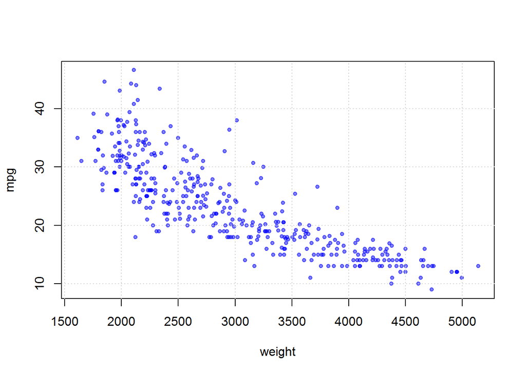

```r
plot(mpg ~ weight, data = Auto,col = rgb(0,0,1,0.5), pch=20);grid()
```

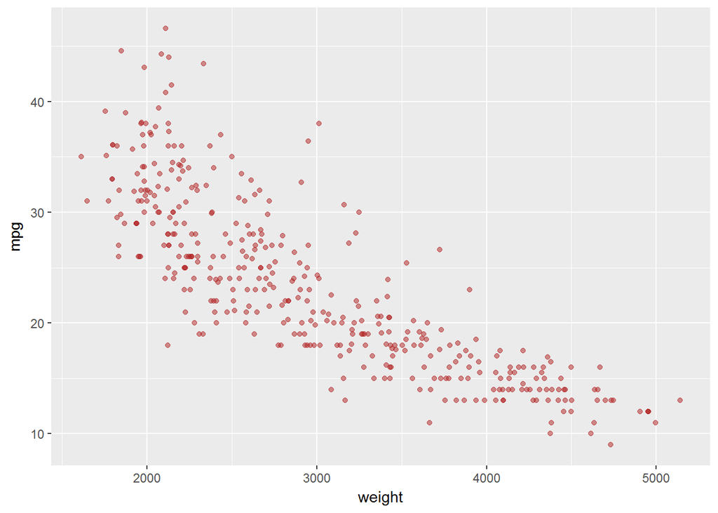

```r
##ggplot version
library(ggplot2)
p <- ggplot(Auto, aes(weight, mpg))
p + geom_point(color="firebrick", alpha=0.5)
```

### 1.4.2 histograms

Back to the Smarket data: can we take a look at the distribution of the data?

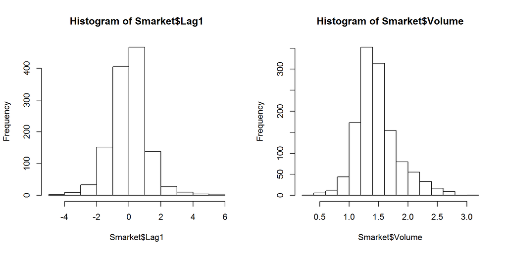

```r
par(mfrow=c(1,2))
hist(Smarket$Lag1)
hist(Smarket$Volume)
```

### 1.4.3 boxplots

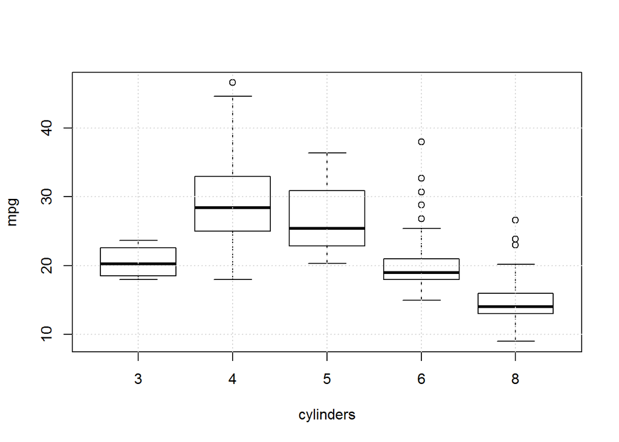

```r
library(ISLR)
data(Auto)

boxplot(mpg ~ cylinders, data=Auto, xlab="cylinders", ylab="mpg");grid()
```

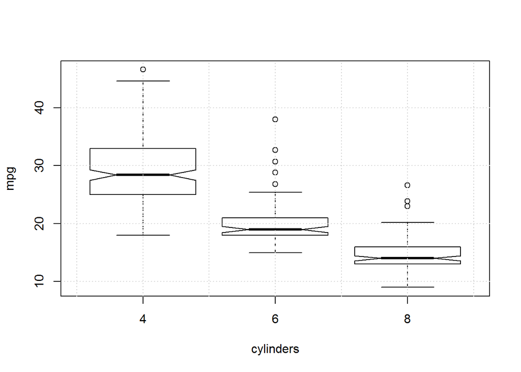

```r
#notched version - for a different data set
boxplot(mpg ~ cylinders, data=subset(Auto, cylinders %in% c(4,6,8)), xlab="cylinders", ylab="mpg", notch=TRUE);grid()
```

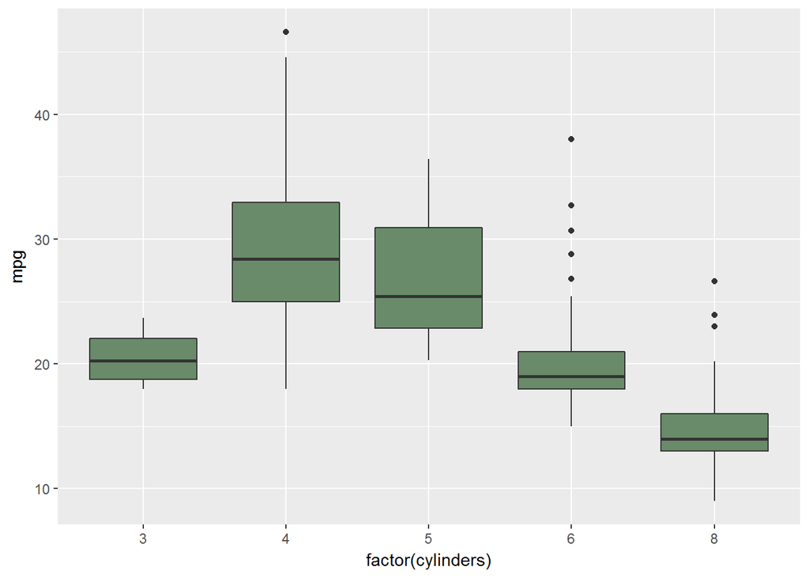

```r
##ggplot version
library(ggplot2)
p <- ggplot(Auto, aes(factor(cylinders), mpg))
p + geom_boxplot(fill="darkseagreen4")
```

### 1.4.4 violin plots

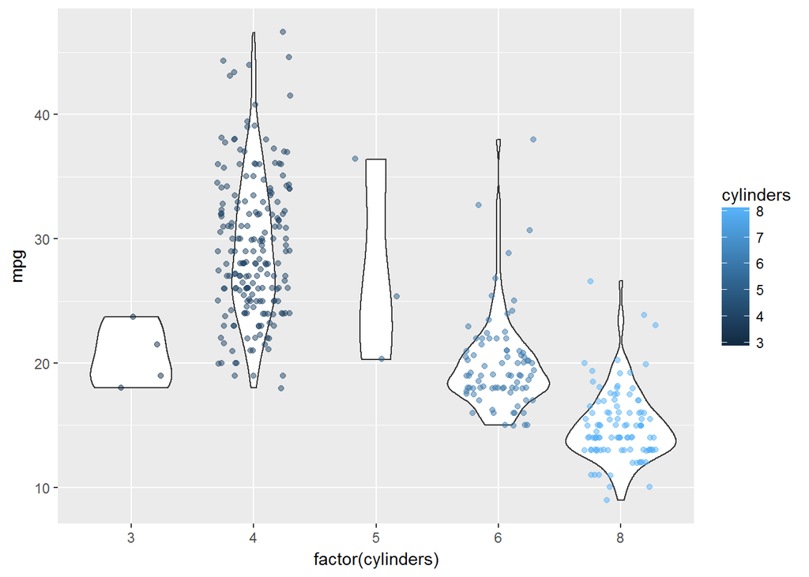

```r
p + geom_violin() + geom_jitter(alpha=0.5, width=0.3, aes(color=cylinders))
```

### 1.4.5 time series plots

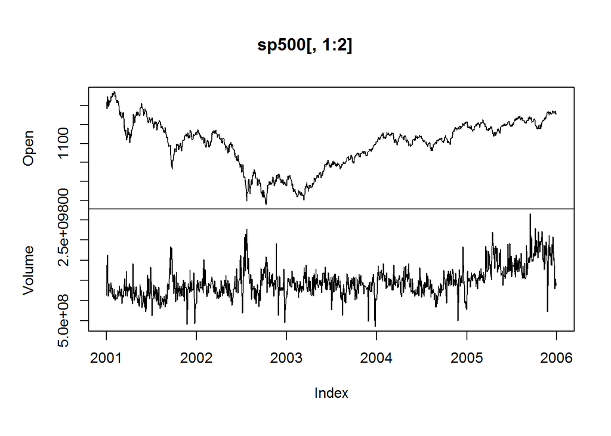

```r
plot(sp500[,1:2])
```

### 1.4.6 interactive paning and zooming:

```r
library(dygraphs)
dy=dygraph(sp500[,"Open"])
dyRangeSelector(dy)
```

[interactive chart not shown]

## 1.5 file I/O

- `scan()`
- `read.csv()`, `read.table()`
- `load()`
- “Import Dataset”

# 2 Day 2 : Basic Data Analysis

## 2.1 computing with probabilities and distributions

Many statistics text books use a coin flipping example as a gentle introduction to the binomial distribution. We would like to achieve the following tasks:

1. sample from a binary vector, e.g. c(0,1) N times, possibly with $p \neq 0.5$
2. compute the mean or sum
3. repeat steps 1 and 2 MANY times, e.g. M=1000
4. possibly plot a histogram and compute tail probabilities
5. somehow pass some of these measures to the user

The R code would look a bit like this:

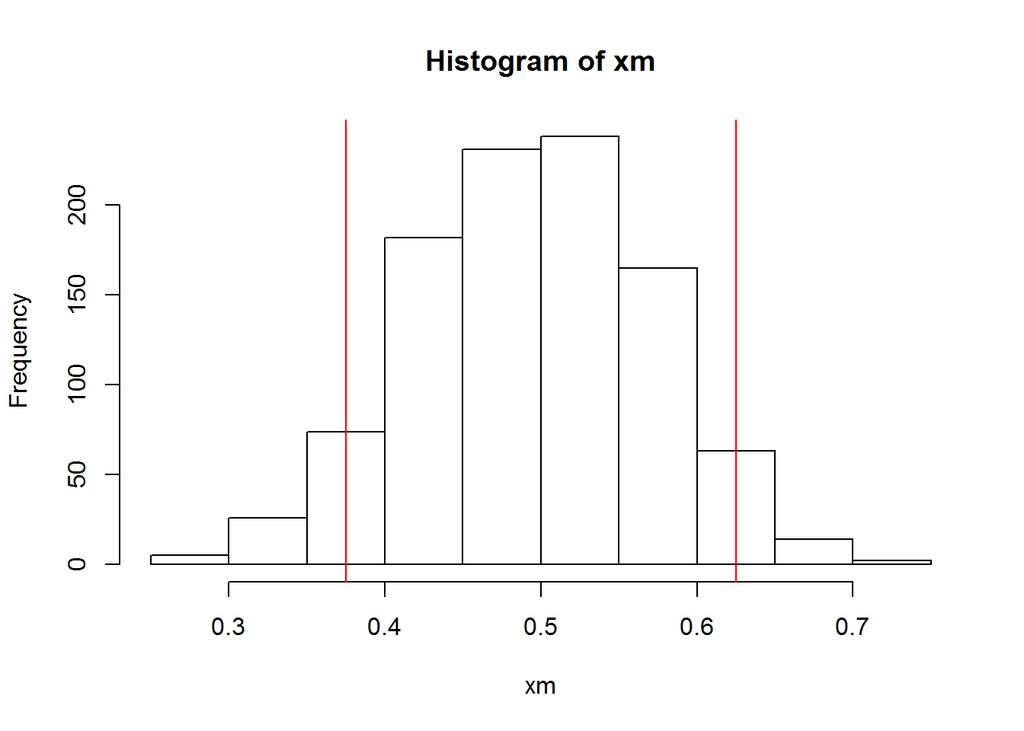

```r
N=40;M=1000;p=0.5;Head2Tail=0.7
  set.seed(123)
  #initialize parameters:
  coin = c(0,1)#values to sample from
  xm = vector();#sample mean or sum
  #loop
  for (i in 1:M){
    x = sample(coin, N, rep=TRUE, prob  = c(1-p,p))
    xm[i] = mean(x)
  }
  hist(xm)
  #get the 5% and 95% quantiles:
  q = quantile(xm,c(0.05,0.95))
  #add vertical lines:
  abline(v=q,col=2)
```

```r
  pObs = sum(xm >= Head2Tail) + sum(xm <= 1-Head2Tail)

  pObs = sum(xm >= Head2Tail | xm <= 1-Head2Tail)
  #pObs = sum(xm >= Head2Tail & xm <= 1-Head2Tail)
```

### 2.1.1 Task: Change the code above into a function

## 2.2 Binomial and Normal Distributions

All standard distributions such as normal, binomial, possion, gamma etc. are built into R. Each distribution comes in 4 version:

1. *Density*: **d**norm(), **d**binom(), **d**pois()
2. *distribution*: **p**norm(), **p**binom(), **p**pois()
3. *quantile*: **q**norm(), **q**binom(), **q**pois()
4. *random generation*: **r**norm(), **r**binom(), **r**pois()

For example:

```r
qnorm(0.975)
```

```
## [1] 1.959964
```

```r
pnorm(-1.96)
```

```
## [1] 0.0249979
```

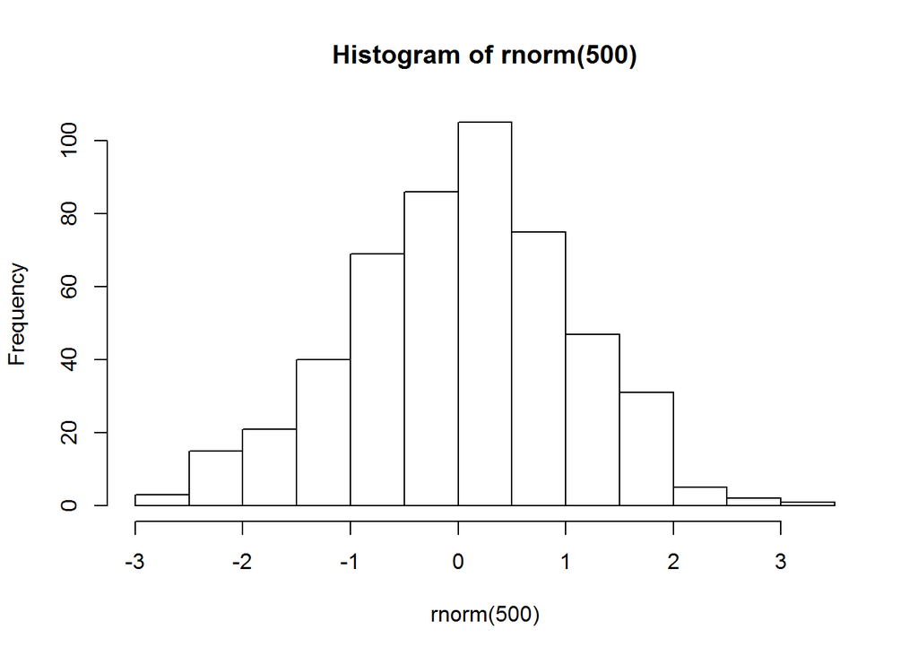

```r
hist(rnorm(500))
```

```r
# Compute P(45 < X < 55) for X Binomial(100,0.5)
sum(dbinom(46:54, 100, 0.5))
```

```
## [1] 0.6317984
```

```r
# Compute P( X < 55) for X Binomial(100,0.5)
pbinom(54, 100, 0.5)
```

```
## [1] 0.8158992
```

### 2.2.1 Task: Create an Rmd file that contains text, code and figures answering the following questions:

1. Random Walker: Imagine you take a succession of 40 random left/right steps of each 1m length. What is the probability that you end up at least 10 meter away from the center?
2. Repeat the exercise with 400 steps and 100 meters.
3. Size matters: insurance company A insures 100 cars, company B 400 cars. The probability of a car being stolen is 10%. Compute the probabilities that more than 15% of the respective fleets are stolen.
4. Faced with a mutliple choice test containing 20 question with 4 choices each you decide in desparation to just guess all answers. What is the probability that you will pass, i.e. get at least 10 correct answers?
5. At a certain intersection, the light for eastbound traffic is red for $15$ seconds, yellow for $5$ seconds, and green for $30$ seconds. Find the probability that out of the next twenty eastbound cars that arrive randomly at the light, fewer than three will be stopped by a red light.

## 2.3 Data manipulation

### 2.3.1 Data: nycflights13

To explore the basic data manipulation verbs of dplyr, we’ll start with the built in `nycflights13` data frame. This dataset contains all 336776 flights that departed from New York City in 2013. The data comes from the US [Bureau of Transportation Statistics](http://www.transtats.bts.gov/DatabaseInfo.asp?DB_ID=120&Link=0), and is documented in `?nycflights13`

```r
library(nycflights13)
dim(flights)
```

```
## [1] 336776     19
```

```r
head(flights)
```

```
## # A tibble: 6 x 19
##    year month   day dep_time sched_dep_time dep_delay arr_time
##   <int> <int> <int>    <int>          <int>     <dbl>    <int>
## 1  2013     1     1      517            515        2.      830
## 2  2013     1     1      533            529        4.      850
## 3  2013     1     1      542            540        2.      923
## 4  2013     1     1      544            545       -1.     1004
## 5  2013     1     1      554            600       -6.      812
## 6  2013     1     1      554            558       -4.      740
## # ... with 12 more variables: sched_arr_time <int>, arr_delay <dbl>,
## #   carrier <chr>, flight <int>, tailnum <chr>, origin <chr>, dest <chr>,
## #   air_time <dbl>, distance <dbl>, hour <dbl>, minute <dbl>,
## #   time_hour <dttm>
```

dplyr can work with data frames as is, but if you’re dealing with large data, it’s worthwhile to convert them to a `tbl_df`: this is a wrapper around a data frame that won’t accidentally print a lot of data to the screen.

### 2.3.2 Single table verbs

Dplyr aims to provide a function for each basic verb of data manipulation:

- `filter()` (and `slice()`)
- `arrange()`
- `select()` (and `rename()`)
- `distinct()`
- `mutate()` (and `transmute()`)
- `summarise()`
- `sample_n()` (and `sample_frac()`)

If you’ve used plyr before, many of these will be familar.

### 2.3.3 Filter rows with `filter()`

`filter()` allows you to select a subset of rows in a data frame. The first argument is the name of the data frame. The second and subsequent arguments are the expressions that filter the data frame:

For example, we can select all flights on January 1st with:

```r
library(dplyr)
filter(flights, month == 1, day == 1)
```

```
## # A tibble: 842 x 19
##     year month   day dep_time sched_dep_time dep_delay arr_time
##    <int> <int> <int>    <int>          <int>     <dbl>    <int>
##  1  2013     1     1      517            515        2.      830
##  2  2013     1     1      533            529        4.      850
##  3  2013     1     1      542            540        2.      923
##  4  2013     1     1      544            545       -1.     1004
##  5  2013     1     1      554            600       -6.      812
##  6  2013     1     1      554            558       -4.      740
##  7  2013     1     1      555            600       -5.      913
##  8  2013     1     1      557            600       -3.      709
##  9  2013     1     1      557            600       -3.      838
## 10  2013     1     1      558            600       -2.      753
## # ... with 832 more rows, and 12 more variables: sched_arr_time <int>,
## #   arr_delay <dbl>, carrier <chr>, flight <int>, tailnum <chr>,
## #   origin <chr>, dest <chr>, air_time <dbl>, distance <dbl>, hour <dbl>,
## #   minute <dbl>, time_hour <dttm>
```

This is equivalent to the more verbose code in base R:

```r
flights[flights$month == 1 & flights$day == 1, ]
```

To select rows by position, use `slice()`:

```r
slice(flights, 1:10)
```

```
## # A tibble: 10 x 19
##     year month   day dep_time sched_dep_time dep_delay arr_time
##    <int> <int> <int>    <int>          <int>     <dbl>    <int>
##  1  2013     1     1      517            515        2.      830
##  2  2013     1     1      533            529        4.      850
##  3  2013     1     1      542            540        2.      923
##  4  2013     1     1      544            545       -1.     1004
##  5  2013     1     1      554            600       -6.      812
##  6  2013     1     1      554            558       -4.      740
##  7  2013     1     1      555            600       -5.      913
##  8  2013     1     1      557            600       -3.      709
##  9  2013     1     1      557            600       -3.      838
## 10  2013     1     1      558            600       -2.      753
## # ... with 12 more variables: sched_arr_time <int>, arr_delay <dbl>,
## #   carrier <chr>, flight <int>, tailnum <chr>, origin <chr>, dest <chr>,
## #   air_time <dbl>, distance <dbl>, hour <dbl>, minute <dbl>,
## #   time_hour <dttm>
```

### 2.3.4 Arrange rows with `arrange()`

`arrange()` works similarly to `filter()` except that instead of filtering or selecting rows, it reorders them. It takes a data frame, and a set of column names (or more complicated expressions) to order by. If you provide more than one column name, each additional column will be used to break ties in the values of preceding columns:

```r
arrange(flights, year, month, day)
```

```
## # A tibble: 336,776 x 19
##     year month   day dep_time sched_dep_time dep_delay arr_time
##    <int> <int> <int>    <int>          <int>     <dbl>    <int>
##  1  2013     1     1      517            515        2.      830
##  2  2013     1     1      533            529        4.      850
##  3  2013     1     1      542            540        2.      923
##  4  2013     1     1      544            545       -1.     1004
##  5  2013     1     1      554            600       -6.      812
##  6  2013     1     1      554            558       -4.      740
##  7  2013     1     1      555            600       -5.      913
##  8  2013     1     1      557            600       -3.      709
##  9  2013     1     1      557            600       -3.      838
## 10  2013     1     1      558            600       -2.      753
## # ... with 336,766 more rows, and 12 more variables: sched_arr_time <int>,
## #   arr_delay <dbl>, carrier <chr>, flight <int>, tailnum <chr>,
## #   origin <chr>, dest <chr>, air_time <dbl>, distance <dbl>, hour <dbl>,
## #   minute <dbl>, time_hour <dttm>
```

Use `desc()` to order a column in descending order:

```r
arrange(flights, desc(arr_delay))
```

```
## # A tibble: 336,776 x 19
##     year month   day dep_time sched_dep_time dep_delay arr_time
##    <int> <int> <int>    <int>          <int>     <dbl>    <int>
##  1  2013     1     9      641            900     1301.     1242
##  2  2013     6    15     1432           1935     1137.     1607
##  3  2013     1    10     1121           1635     1126.     1239
##  4  2013     9    20     1139           1845     1014.     1457
##  5  2013     7    22      845           1600     1005.     1044
##  6  2013     4    10     1100           1900      960.     1342
##  7  2013     3    17     2321            810      911.      135
##  8  2013     7    22     2257            759      898.      121
##  9  2013    12     5      756           1700      896.     1058
## 10  2013     5     3     1133           2055      878.     1250
## # ... with 336,766 more rows, and 12 more variables: sched_arr_time <int>,
## #   arr_delay <dbl>, carrier <chr>, flight <int>, tailnum <chr>,
## #   origin <chr>, dest <chr>, air_time <dbl>, distance <dbl>, hour <dbl>,
## #   minute <dbl>, time_hour <dttm>
```

### 2.3.5 Select columns with `select()`

Often you work with large datasets with many columns but only a few are actually of interest to you. `select()` allows you to rapidly zoom in on a useful subset using operations that usually only work on numeric variable positions:

```r
# Select columns by name
select(flights, year, month, day)
```

```
## # A tibble: 336,776 x 3
##     year month   day
##    <int> <int> <int>
##  1  2013     1     1
##  2  2013     1     1
##  3  2013     1     1
##  4  2013     1     1
##  5  2013     1     1
##  6  2013     1     1
##  7  2013     1     1
##  8  2013     1     1
##  9  2013     1     1
## 10  2013     1     1
## # ... with 336,766 more rows
```

```r
# Select all columns between year and day (inclusive)
select(flights, year:day)
```

```
## # A tibble: 336,776 x 3
##     year month   day
##    <int> <int> <int>
##  1  2013     1     1
##  2  2013     1     1
##  3  2013     1     1
##  4  2013     1     1
##  5  2013     1     1
##  6  2013     1     1
##  7  2013     1     1
##  8  2013     1     1
##  9  2013     1     1
## 10  2013     1     1
## # ... with 336,766 more rows
```

```r
# Select all columns except those from year to day (inclusive)
select(flights, -(year:day))
```

```
## # A tibble: 336,776 x 16
##    dep_time sched_dep_time dep_delay arr_time sched_arr_time arr_delay
##       <int>          <int>     <dbl>    <int>          <int>     <dbl>
##  1      517            515        2.      830            819       11.
##  2      533            529        4.      850            830       20.
##  3      542            540        2.      923            850       33.
##  4      544            545       -1.     1004           1022      -18.
##  5      554            600       -6.      812            837      -25.
##  6      554            558       -4.      740            728       12.
##  7      555            600       -5.      913            854       19.
##  8      557            600       -3.      709            723      -14.
##  9      557            600       -3.      838            846       -8.
## 10      558            600       -2.      753            745        8.
## # ... with 336,766 more rows, and 10 more variables: carrier <chr>,
## #   flight <int>, tailnum <chr>, origin <chr>, dest <chr>, air_time <dbl>,
## #   distance <dbl>, hour <dbl>, minute <dbl>, time_hour <dttm>
```

You can rename variables with `select()` by using named arguments:

```r
select(flights, tail_num = tailnum)
```

```
## # A tibble: 336,776 x 1
##    tail_num
##    <chr>
##  1 N14228
##  2 N24211
##  3 N619AA
##  4 N804JB
##  5 N668DN
##  6 N39463
##  7 N516JB
##  8 N829AS
##  9 N593JB
## 10 N3ALAA
## # ... with 336,766 more rows
```

But because `select()` drops all the variables not explicitly mentioned, it’s not that useful. Instead, use `rename()`:

```r
rename(flights, tail_num = tailnum)
```

```
## # A tibble: 336,776 x 19
##     year month   day dep_time sched_dep_time dep_delay arr_time
##    <int> <int> <int>    <int>          <int>     <dbl>    <int>
##  1  2013     1     1      517            515        2.      830
##  2  2013     1     1      533            529        4.      850
##  3  2013     1     1      542            540        2.      923
##  4  2013     1     1      544            545       -1.     1004
##  5  2013     1     1      554            600       -6.      812
##  6  2013     1     1      554            558       -4.      740
##  7  2013     1     1      555            600       -5.      913
##  8  2013     1     1      557            600       -3.      709
##  9  2013     1     1      557            600       -3.      838
## 10  2013     1     1      558            600       -2.      753
## # ... with 336,766 more rows, and 12 more variables: sched_arr_time <int>,
## #   arr_delay <dbl>, carrier <chr>, flight <int>, tail_num <chr>,
## #   origin <chr>, dest <chr>, air_time <dbl>, distance <dbl>, hour <dbl>,
## #   minute <dbl>, time_hour <dttm>
```

### 2.3.6 Extract distinct (unique) rows

Use `distinct()`to find unique values in a table:

```r
distinct(flights, tailnum)
```

```
## # A tibble: 4,044 x 1
##    tailnum
##    <chr>
##  1 N14228
##  2 N24211
##  3 N619AA
##  4 N804JB
##  5 N668DN
##  6 N39463
##  7 N516JB
##  8 N829AS
##  9 N593JB
## 10 N3ALAA
## # ... with 4,034 more rows
```

```r
distinct(flights, origin, dest)
```

```
## # A tibble: 224 x 2
##    origin dest
##    <chr>  <chr>
##  1 EWR    IAH
##  2 LGA    IAH
##  3 JFK    MIA
##  4 JFK    BQN
##  5 LGA    ATL
##  6 EWR    ORD
##  7 EWR    FLL
##  8 LGA    IAD
##  9 JFK    MCO
## 10 LGA    ORD
## # ... with 214 more rows
```

(This is very similar to `base::unique()` but should be much faster.)

### 2.3.7 Add new columns with `mutate()`

Besides selecting sets of existing columns, it’s often useful to add new columns that are functions of existing columns. This is the job of `mutate()`:

```r
mutate(flights,
  gain = arr_delay - dep_delay,
  speed = distance / air_time * 60)
```

```
## # A tibble: 336,776 x 21
##     year month   day dep_time sched_dep_time dep_delay arr_time
##    <int> <int> <int>    <int>          <int>     <dbl>    <int>
##  1  2013     1     1      517            515        2.      830
##  2  2013     1     1      533            529        4.      850
##  3  2013     1     1      542            540        2.      923
##  4  2013     1     1      544            545       -1.     1004
##  5  2013     1     1      554            600       -6.      812
##  6  2013     1     1      554            558       -4.      740
##  7  2013     1     1      555            600       -5.      913
##  8  2013     1     1      557            600       -3.      709
##  9  2013     1     1      557            600       -3.      838
## 10  2013     1     1      558            600       -2.      753
## # ... with 336,766 more rows, and 14 more variables: sched_arr_time <int>,
## #   arr_delay <dbl>, carrier <chr>, flight <int>, tailnum <chr>,
## #   origin <chr>, dest <chr>, air_time <dbl>, distance <dbl>, hour <dbl>,
## #   minute <dbl>, time_hour <dttm>, gain <dbl>, speed <dbl>
```

mutate allows you to refer to columns that you’ve just created:

```r
mutate(flights,
  gain = arr_delay - dep_delay,
  gain_per_hour = gain / (air_time / 60)
)
```

```
## # A tibble: 336,776 x 21
##     year month   day dep_time sched_dep_time dep_delay arr_time
##    <int> <int> <int>    <int>          <int>     <dbl>    <int>
##  1  2013     1     1      517            515        2.      830
##  2  2013     1     1      533            529        4.      850
##  3  2013     1     1      542            540        2.      923
##  4  2013     1     1      544            545       -1.     1004
##  5  2013     1     1      554            600       -6.      812
##  6  2013     1     1      554            558       -4.      740
##  7  2013     1     1      555            600       -5.      913
##  8  2013     1     1      557            600       -3.      709
##  9  2013     1     1      557            600       -3.      838
## 10  2013     1     1      558            600       -2.      753
## # ... with 336,766 more rows, and 14 more variables: sched_arr_time <int>,
## #   arr_delay <dbl>, carrier <chr>, flight <int>, tailnum <chr>,
## #   origin <chr>, dest <chr>, air_time <dbl>, distance <dbl>, hour <dbl>,
## #   minute <dbl>, time_hour <dttm>, gain <dbl>, gain_per_hour <dbl>
```

### 2.3.8 Summarise values with `summarise()`

The last verb is `summarise()`. It collapses a data frame to a single row (this is exactly equivalent to `plyr::summarise()`):

```r
summarise(flights,
  delay = mean(dep_delay, na.rm = TRUE))
```

```
## # A tibble: 1 x 1
##   delay
##   <dbl>
## 1  12.6
```

Below, we’ll see how this verb can be very useful.

### 2.3.9 Grouped operations

These verbs are useful on their own, but they become really powerful when you apply them to groups of observations within a dataset. In dplyr, you do this by with the `group_by()` function. It breaks down a dataset into specified groups of rows. When you then apply the verbs above on the resulting object they’ll be automatically applied “by group”. Most importantly, all this is achieved by using the same exact syntax you’d use with an ungrouped object.

In the following example, we split the complete dataset into individual planes and then summarise each plane by counting the number of flights (`count = n()`) and computing the average distance (`dist = mean(Distance, na.rm = TRUE)`) and arrival delay (`delay = mean(ArrDelay, na.rm = TRUE)`). We then use ggplot2 to display the output.

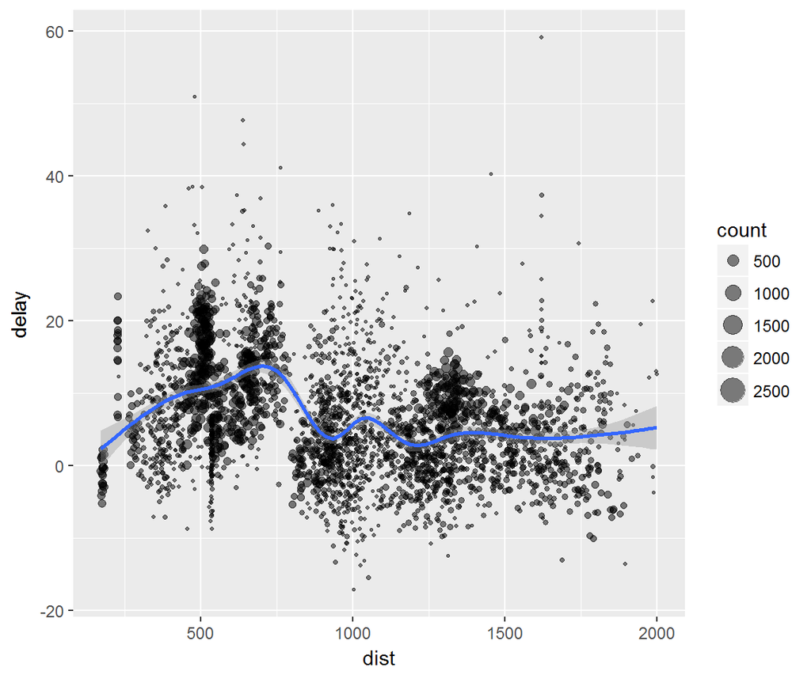

```r
by_tailnum <- group_by(flights, tailnum)
delay <- summarise(by_tailnum,
  count = n(),
  dist = mean(distance, na.rm = TRUE),
  delay = mean(arr_delay, na.rm = TRUE))
delay <- filter(delay, count > 20, dist < 2000)

# Interestingly, the average delay is only slightly related to the
# average distance flown by a plane.
library(ggplot2)
ggplot(delay, aes(dist, delay)) +
  geom_point(aes(size = count), alpha = 1/2) +
  geom_smooth() +
  scale_size_area()
```

You use `summarise()` with **aggregate functions**, which take a vector of values and return a single number. There are many useful examples of such functions in base R like `min()`, `max()`, `mean()`, `sum()`, `sd()`, `median()`, and `IQR()`. dplyr provides a handful of others:

- `n()`: the number of observations in the current group
- `n_distinct(x)`:the number of unique values in `x`.
- `first(x)`, `last(x)` and `nth(x, n)` - these work similarly to `x[1]`, `x[length(x)]`, and `x[n]` but give you more control over the result if the value is missing.

For example, we could use these to find the number of planes and the number of flights that go to each possible destination:

```r
destinations <- group_by(flights, dest)
summarise(destinations,
  planes = n_distinct(tailnum),
  flights = n()
)
```

```
## # A tibble: 105 x 3
##    dest  planes flights
##    <chr>  <int>   <int>
##  1 ABQ      108     254
##  2 ACK       58     265
##  3 ALB      172     439
##  4 ANC        6       8
##  5 ATL     1180   17215
##  6 AUS      993    2439
##  7 AVL      159     275
##  8 BDL      186     443
##  9 BGR       46     375
## 10 BHM       45     297
## # ... with 95 more rows
```

### 2.3.10 Reshaping data

can be done in two ways.

1. The **reshape2** commands `melt()` and `dcast()`
2. The equivalent commands in **tidyr** are `gather()` and `spread()` respectively.

We will focus only on the latter:

```r
olddata_wide <- read.table(header=TRUE, text='
 subject sex control cond1 cond2
       1   M     7.9  12.3  10.7
       2   F     6.3  10.6  11.1
       3   F     9.5  13.1  13.8
       4   M    11.5  13.4  12.9
')
# Make sure the subject column is a factor
olddata_wide$subject <- factor(olddata_wide$subject)
```

From wide to long, Use **gather**:

```r
library(tidyr)

# The arguments to gather():
# - data: Data object
# - key: Name of new key column (made from names of data columns)
# - value: Name of new value column
# - ...: Names of source columns that contain values
# - factor_key: Treat the new key column as a factor (instead of character vector)
data_long <- gather(olddata_wide, condition, measurement, control:cond2, factor_key=TRUE)
data_long
```

```
##    subject sex condition measurement
## 1        1   M   control         7.9
## 2        2   F   control         6.3
## 3        3   F   control         9.5
## 4        4   M   control        11.5
## 5        1   M     cond1        12.3
## 6        2   F     cond1        10.6
## 7        3   F     cond1        13.1
## 8        4   M     cond1        13.4
## 9        1   M     cond2        10.7
## 10       2   F     cond2        11.1
## 11       3   F     cond2        13.8
## 12       4   M     cond2        12.9
```

In this example, the source columns that are gathered are specified with control:cond2. This means to use all the columns, positionally, between control and cond2. Another way of doing it is to name the columns individually, as in:

```r
gather(olddata_wide, condition, measurement, control, cond1, cond2)
```

```
##    subject sex condition measurement
## 1        1   M   control         7.9
## 2        2   F   control         6.3
## 3        3   F   control         9.5
## 4        4   M   control        11.5
## 5        1   M     cond1        12.3
## 6        2   F     cond1        10.6
## 7        3   F     cond1        13.1
## 8        4   M     cond1        13.4
## 9        1   M     cond2        10.7
## 10       2   F     cond2        11.1
## 11       3   F     cond2        13.8
## 12       4   M     cond2        12.9
```

If you need to use gather() programmatically, you may need to use variables containing column names. To do this, you should use the gather_() function instead, which takes strings instead of bare (unquoted) column names.

```r
keycol <- "condition"
valuecol <- "measurement"
gathercols <- c("control", "cond1", "cond2")
gather_(olddata_wide, keycol, valuecol, gathercols)
```

```
##    subject sex condition measurement
## 1        1   M   control         7.9
## 2        2   F   control         6.3
## 3        3   F   control         9.5
## 4        4   M   control        11.5
## 5        1   M     cond1        12.3
## 6        2   F     cond1        10.6
## 7        3   F     cond1        13.1
## 8        4   M     cond1        13.4
## 9        1   M     cond2        10.7
## 10       2   F     cond2        11.1
## 11       3   F     cond2        13.8
## 12       4   M     cond2        12.9
```

From long to wide, use **spread**:

```r
library(tidyr)

# The arguments to spread():
# - data: Data object
# - key: Name of column containing the new column names
# - value: Name of column containing values
data_wide <- spread(data_long, condition, measurement)
data_wide
```

```
##   subject sex control cond1 cond2
## 1       1   M     7.9  12.3  10.7
## 2       2   F     6.3  10.6  11.1
## 3       3   F     9.5  13.1  13.8
## 4       4   M    11.5  13.4  12.9
```

Optional: A few things to make the data look nicer.

```r
# Rename cond1 to first, and cond2 to second
names(data_wide)[names(data_wide)=="cond1"] <- "first"
names(data_wide)[names(data_wide)=="cond2"] <- "second"

# Reorder the columns
data_wide <- data_wide[, c(1,2,5,3,4)]
data_wide
```

```
##   subject sex second control first
## 1       1   M   10.7     7.9  12.3
## 2       2   F   11.1     6.3  10.6
## 3       3   F   13.8     9.5  13.1
## 4       4   M   12.9    11.5  13.4
```

The order of factor levels determines the order of the columns. The level order can be changed before reshaping, or the columns can be re-ordered afterward.

## 2.4 Titanic

```r
train <- read.csv("data/TitanicTrain.csv")
```

The disaster was famous for saving “women and children first”, so let’s take a look at the Sex and Age variables to see if any patterns are evident. We’ll start with the gender of the passengers. After reloading the data into R, take a look at the summary of this variable:

```r
round(prop.table(table(train$Sex, train$Survived),1),2)
```

```
##
##             0    1
##   female 0.26 0.74
##   male   0.81 0.19
```

Let’s create a new variable, “Child”, to indicate whether the passenger is below the age of 18:

```r
train$Child <- 0
train$Child[train$Age < 18] <- 1
```

Now we want to create a table with both gender and age to see the survival proportions for different subsets. Recall the dplyr version of the aggregate function:

```r
suppressPackageStartupMessages(require(dplyr))
summarise(group_by(train, Sex, Child), round(mean(Survived),2), length(Survived))
```

```
## # A tibble: 4 x 4
## # Groups:   Sex [?]
##   Sex    Child `round(mean(Survived), 2)` `length(Survived)`
##   <fct>  <dbl>                      <dbl>              <int>
## 1 female    0.                      0.750                259
## 2 female    1.                      0.690                 55
## 3 male      0.                      0.170                519
## 4 male      1.                      0.400                 58
```

While the class variable is limited to a manageable 3 values, the fare is again a continuous variable that needs to be reduced to something that can be easily tabulated. Let’s bin the fares into less than $10, between $10 and $20, $20 to $30 and more than $30 and store it to a new variable:

```r
train$Fare2 <- '30+'
 train$Fare2[train$Fare < 30 & train$Fare >= 20] <- '20-30'
 train$Fare2[train$Fare < 20 & train$Fare >= 10] <- '10-20'
train$Fare2[train$Fare < 10] <- '<10'
```

- Use the summarise function to compute the proportions and in each group defined by child, gender and Fare2:
- Find strong differences between male/female survival probabilities.
- Partition your data into even finer subgroups, e.g. age and/or embarkation port and repeat.

```
## # A tibble: 41 x 6
## # Groups:   Child, Fare2, Sex [?]
##    Child Fare2 Sex    Embarked `round(mean(Survived), 2)` `length(Survive~
##    <dbl> <chr> <fct>  <fct>                         <dbl>            <int>
##  1    0. <10   female C                            1.00                  2
##  2    0. <10   female Q                            0.700                23
##  3    0. <10   female S                            0.440                32
##  4    0. <10   male   C                            0.130                30
##  5    0. <10   male   Q                            0.0700               28
##  6    0. <10   male   S                            0.100               201
##  7    0. 10-20 female C                            0.440                 9
##  8    0. 10-20 female Q                            0.830                 6
##  9    0. 10-20 female S                            0.760                45
## 10    0. 10-20 male   C                            0.450                11
## # ... with 31 more rows
```

## 2.5 Descriptive statistics

### 2.5.1 Measures of Central tendency

```r
mean(flights$dep_delay)
```

```
## [1] NA
```

```r
mean(flights$dep_delay, na.rm=T)
```

```
## [1] 12.63907
```

```r
median(flights$dep_delay, na.rm=T)
```

```
## [1] -2
```

```r
#robustness
mean(flights$dep_delay, na.rm=T, trim = 0.1)
```

```
## [1] 3.320257
```

### 2.5.2 Dispersion measures

Only sample stdev is included!

```r
#var

sd(flights$dep_delay, na.rm=T)
```

```
## [1] 40.21006
```

```r
IQR(flights$dep_delay, na.rm=T)
```

```
## [1] 16
```

```r
mad(flights$dep_delay, na.rm=T)
```

```
## [1] 5.9304
```

### 2.5.3 Descriptive boxplots

```r
#define our own transformation
require(scales) # trans_new() is in the scales library
sign_sqrt_trans = function() trans_new("sign_sqrt", function(x) sign(x)*sqrt(abs(x)), function(x) sign(x)*x^2)
```

### 2.5.4 Delays by carrier

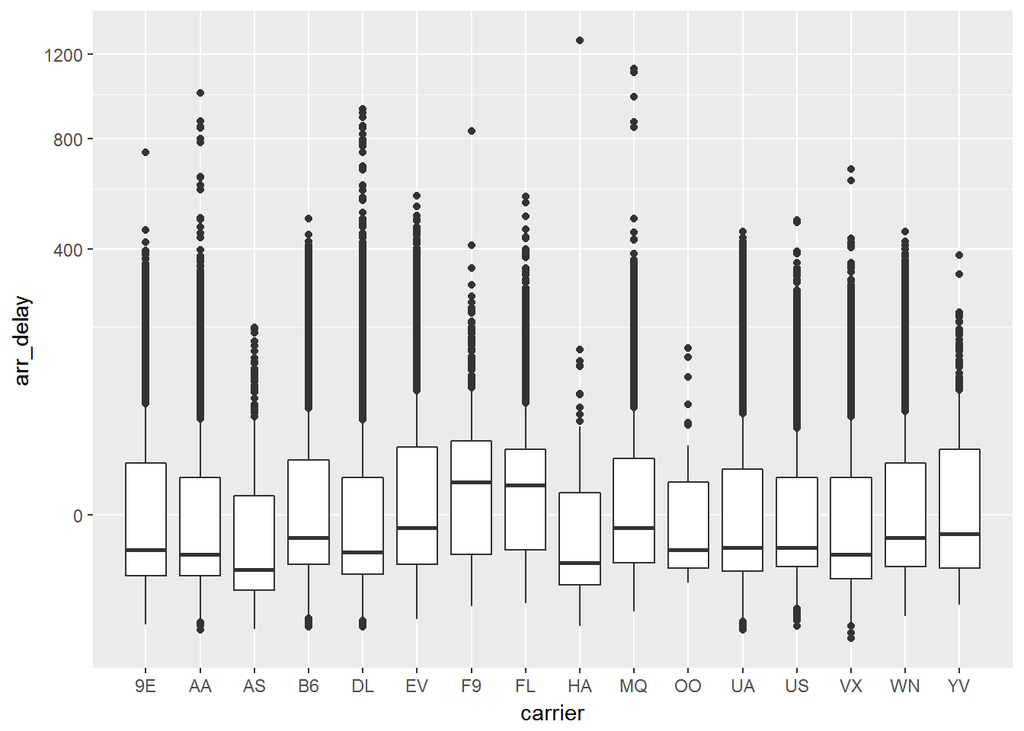

```r
if (baseR){
  boxplot(arr_delay ~ carrier, data=flights)
  grid()
} else {
  p = ggplot(flights, aes( carrier,arr_delay))
  p + geom_boxplot() + coord_trans(y="sign_sqrt") #+ scale_y_sqrt()
}
```

There appear to be significant delays by time-of-day:

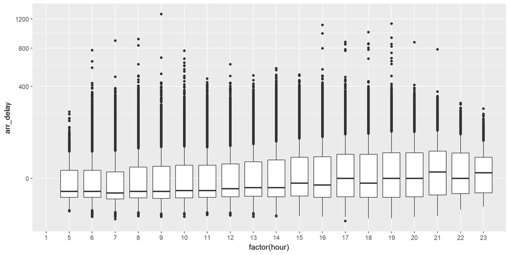

```r
if (baseR){
  boxplot(arr_delay ~ hour, data=flights)
  grid()
} else {
  p = ggplot(flights, aes( factor(hour),arr_delay))
  p + geom_boxplot() + coord_trans(y="sign_sqrt") #+ scale_y_sqrt()
}
```

## 2.6 Basic statistical tests

I have prepared a data file for you:

```r
print(load("data/BirthWeights.rda"))
```

```
## [1] "x"
```

```r
class(x$gender)
```

```
## [1] "factor"
```

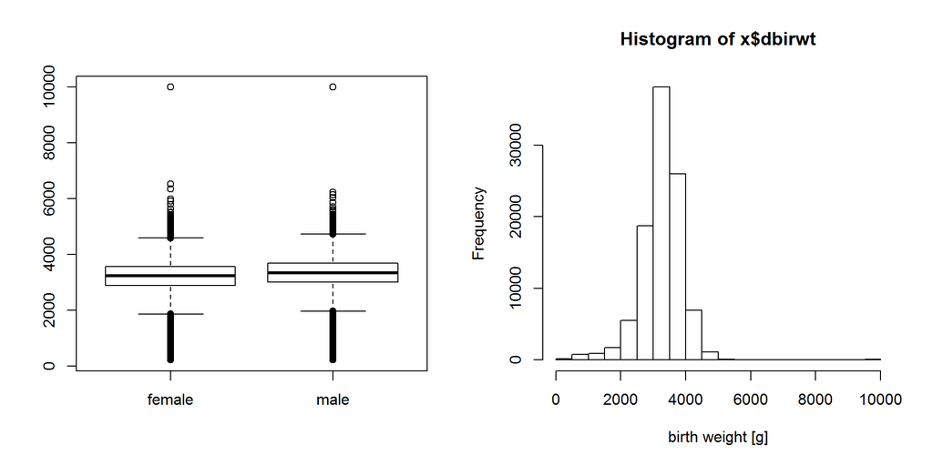

```r
#split the plotting region into 2 columns:
par(mfrow=c(1,2))
boxplot(dbirwt ~ gender, data=x)
hist(x$dbirwt, xlab="birth weight [g]")
```

### 2.6.1 remove outliers

```r
#either:
ii = which(x$dbirwt> 8000)
x = x[-ii,]

#or:
x = subset(x, dbirwt <= 8000)
```

### 2.6.2 density plot

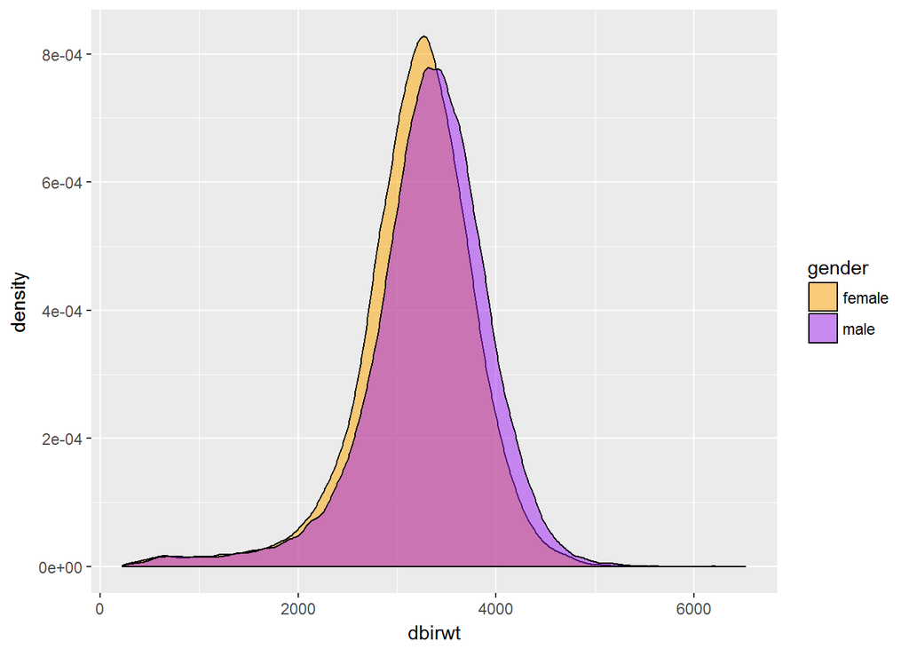

```r
library(ggplot2)
ggplot(x, aes(dbirwt, fill=gender)) + geom_density(alpha=.5) +
  scale_fill_manual(values = c("orange", "purple")) # +   theme(legend.position = "none")
```

### 2.6.3 t-test

Can we detect the difference in birth weights?

```r
boys = subset(x, gender == "male")$dbirwt
girls = subset(x, gender == "female")$dbirwt

t.test(x=boys, y=girls)
```

```
##
##  Welch Two Sample t-test
##
## data:  boys and girls
## t = 30.07, df = 99925, p-value < 2.2e-16
## alternative hypothesis: true difference in means is not equal to 0
## 95 percent confidence interval:
##  109.6238 124.9108
## sample estimates:
## mean of x mean of y
##  3309.642  3192.375
```

Would a small sample suffice?

```r
set.seed(1234)

b=sample(boys,100);g=sample(girls,100)

t.test(b,g)
```

```
##
##  Welch Two Sample t-test
##
## data:  b and g
## t = 0.51544, df = 195.65, p-value = 0.6068
## alternative hypothesis: true difference in means is not equal to 0
## 95 percent confidence interval:
##  -148.5721  253.7121
## sample estimates:
## mean of x mean of y
##   3225.44   3172.87
```

What about these non integer degrees of freedom??

### 2.6.4 F-test for variances

```r
var.test(b,g)
```

```
##
##  F test to compare two variances
##
## data:  b and g
## F = 1.2461, num df = 99, denom df = 99, p-value = 0.2753
## alternative hypothesis: true ratio of variances is not equal to 1
## 95 percent confidence interval:
##  0.8384494 1.8520431
## sample estimates:
## ratio of variances
##           1.246132
```

### 2.6.5 prop-test

```r
(gs = table(train$Sex, train$Survived))
```

```
##
##            0   1
##   female  81 233
##   male   468 109
```

```r
prop.test(gs)
```

```
##
##  2-sample test for equality of proportions with continuity
##  correction
##
## data:  gs
## X-squared = 260.72, df = 1, p-value < 2.2e-16
## alternative hypothesis: two.sided
## 95 percent confidence interval:
##  -0.6135708 -0.4926894
## sample estimates:
##    prop 1    prop 2
## 0.2579618 0.8110919
```

### 2.6.6 Exact Binomial Test

```r
binom.test(gs[1,2:1], p=0.75)
```

```
##
##  Exact binomial test
##
## data:  gs[1, 2:1]
## number of successes = 233, number of trials = 314, p-value =
## 0.7447
## alternative hypothesis: true probability of success is not equal to 0.75
## 95 percent confidence interval:
##  0.6899084 0.7895366
## sample estimates:
## probability of success
##              0.7420382
```

## 2.7 Linear Models, correlation

#### 2.7.0.1 Are arrival and departure delay correlated?

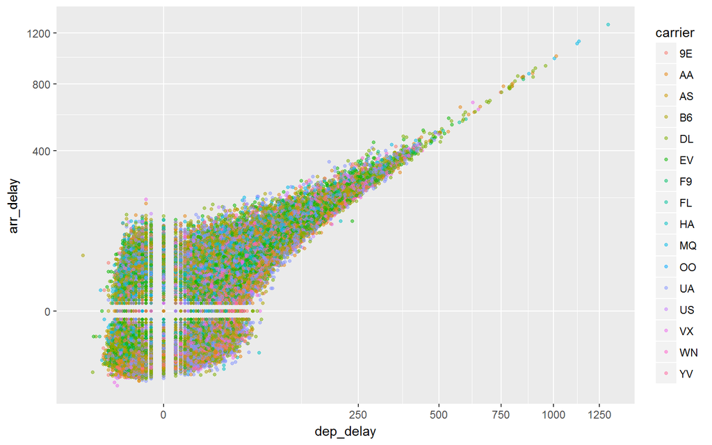

```r
if (baseR){
  plot(arr_delay ~ dep_delay, data=flights, pch=20,cex=0.5,col=carrier)
  grid()
} else {
  p = ggplot(flights, aes( dep_delay,arr_delay, col=carrier ))
  p + geom_point( alpha=0.5, size=1) + coord_trans(x="sign_sqrt", y="sign_sqrt") # +  geom_smooth(method=lm)
}
```

```r
cor(flights$dep_delay,flights$arr_delay, use = "complete.obs",method = "pearson")
```

```
## [1] 0.9148028
```

```r
#slooow
#cor(flights$dep_delay,flights$arr_delay, use = "complete.obs",method = "kendall")

#cor(flights$dep_delay,flights$arr_delay, use = "complete.obs",method = "spearman")

Shortdelays = filter(flights, abs(arr_delay)<100 & abs(dep_delay)<100)

cor(Shortdelays$dep_delay,Shortdelays$arr_delay, use = "complete.obs",method = "pearson")
```

```
## [1] 0.7562735
```

```r
#plot(arr_delay ~ dep_delay,data=Shortdelays)
```

## 2.8 simple regression

### 2.8.1 mpg vs. weight

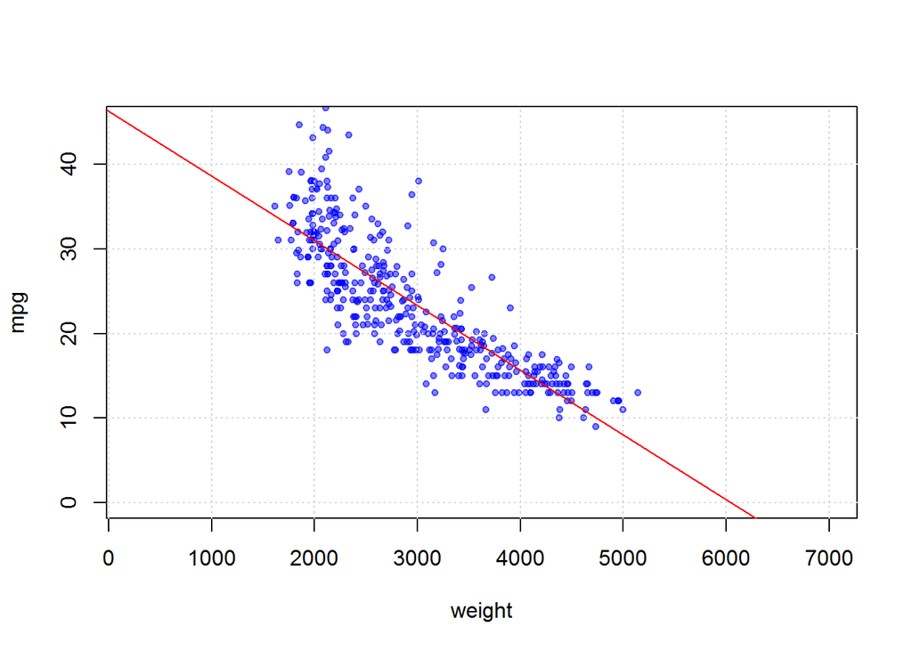

```r
library(ISLR);data(Auto)
plot(mpg ~ weight, data = Auto,col = rgb(0,0,1,0.5), pch=20,xlim=c(250, 7000), ylim = c(0,45));grid()
LSfit = lm(mpg ~ weight, data = Auto)

#overlay regression line
abline(LSfit, col=2)
```

```r
#summary
summary(LSfit)
```

```
##
## Call:
## lm(formula = mpg ~ weight, data = Auto)
##
## Residuals:
##      Min       1Q   Median       3Q      Max
## -11.9736  -2.7556  -0.3358   2.1379  16.5194
##
## Coefficients:
##              Estimate Std. Error t value Pr(>|t|)
## (Intercept) 46.216524   0.798673   57.87   <2e-16 ***
## weight      -0.007647   0.000258  -29.64   <2e-16 ***
## ---
## Signif. codes:  0 '***' 0.001 '**' 0.01 '*' 0.05 '.' 0.1 ' ' 1
##
## Residual standard error: 4.333 on 390 degrees of freedom
## Multiple R-squared:  0.6926, Adjusted R-squared:  0.6918
## F-statistic: 878.8 on 1 and 390 DF,  p-value: < 2.2e-16
```

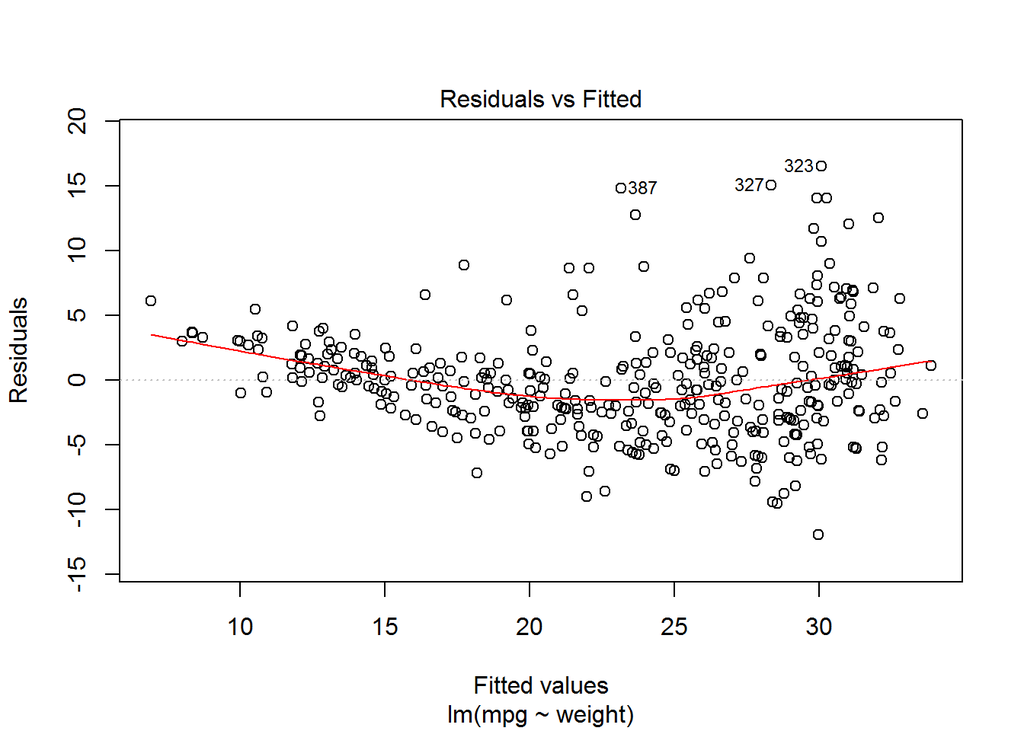

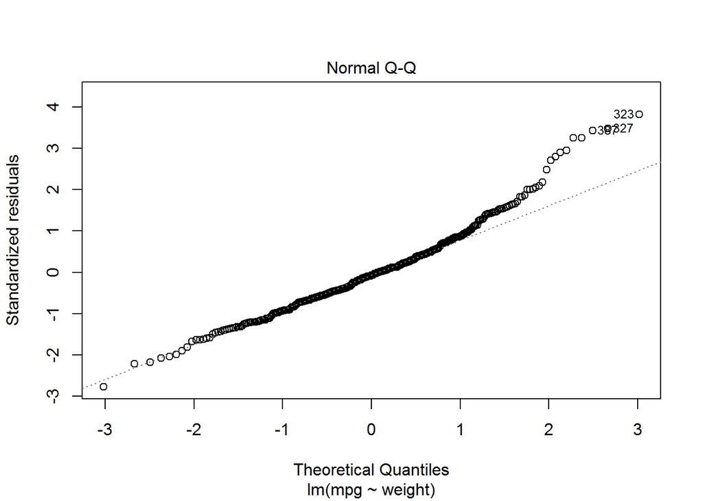

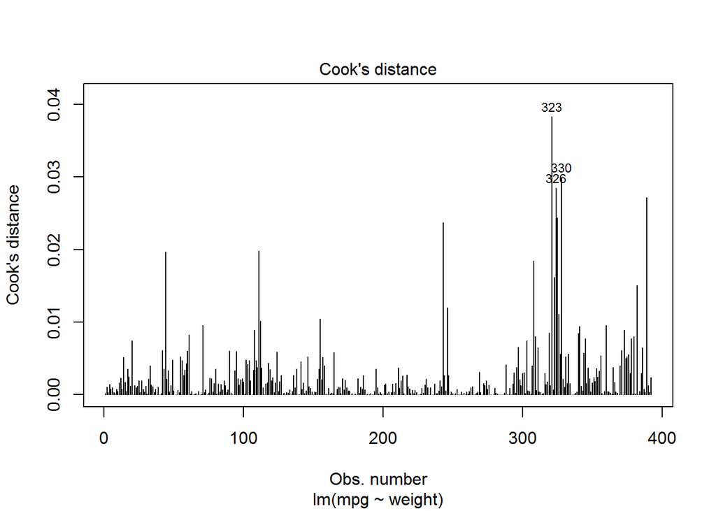

```r
#diagnostics
plot(LSfit, c(1,2,4))
```

**Tasks**

1. Predict mpg for a car that weighs 5000 lbs.
2. Confidence Interval for slope
3. Are the least squares assumptions met?
4. Add 3 outliers to the data:
- weight=500, mpg = 40
- weight=$10^4$, mpg = 80
- weight=3000, mpg = 80

Points that fall horizontally far from the line are points of high leverage; these points can strongly influence the slope of the least squares line. If one of these high leverage points does appear to actually invoke its in uence on the slope of the line then we call it an in uential point. Usually we can say a point is influential if, had we fitted the line without it, the influential point would have been unusually far from the least squares line.

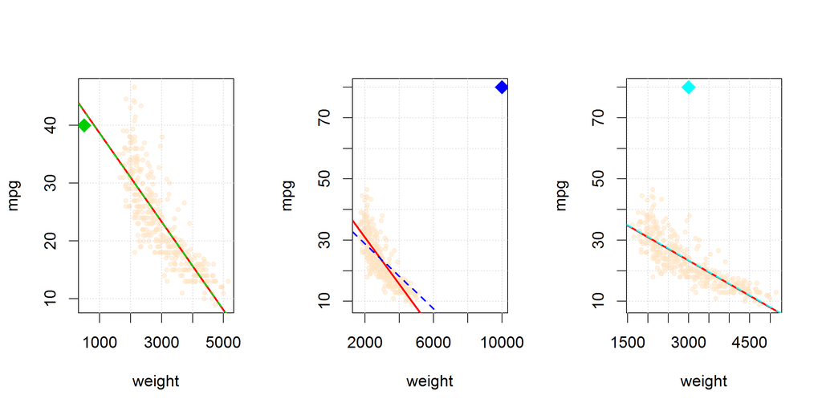

```r
par(mfrow=c(1,3), cex=1.4)

outlrs = cbind(weight=c(500,10000,3000),mpg=c(40,80,80))
Auto2 = Auto

fit=list()
for (i in 1:3){
  Auto2[1,c("weight","mpg")] = outlrs[i,]

  plot(mpg ~ weight, data = Auto2,col = rgb(1,0.894,0.769,0.5), pch=20);grid()
  #overlay regression line
  abline(LSfit, col=2, lwd=2.5)
  fit[[i]] = lm(mpg ~ weight, data = Auto2)
  points(Auto2[1,c("weight","mpg")], col = i+2, pch = 18, cex = 2)
  #overlay regression line
  abline(fit[[i]], col=i+2,lwd=2, lty=2)
  #plot(fit[[i]],5)
}
```

# 3 Day 3, Advanced Data Analysis

## 3.1 Time series

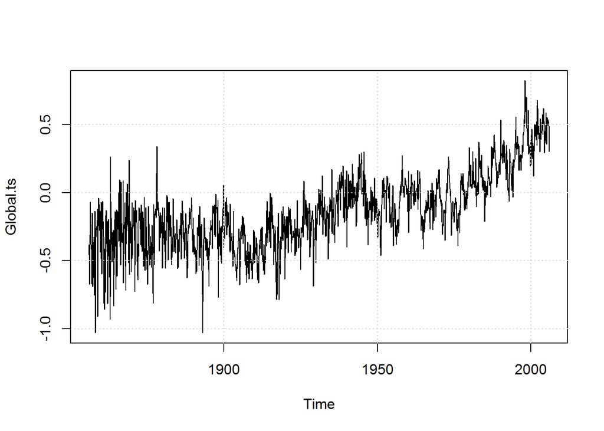

```r
Global <- scan("data/global.dat")
 Global.ts <- ts(Global, st = c(1856, 1), end = c(2005, 12),
fr = 12)
 Global.annual <- aggregate(Global.ts, FUN = mean)
 plot(Global.ts);grid()
```

### 3.1.1 Interactive Data Exploration

```r
library(dygraphs)
dygraph(Global.ts) %>%  dyRangeSelector()
```

[interactive chart not shown]

The following regression model is fitted to the global temperature over this period, and approximate 95% confidence intervals are given for the parameters using confint. The explanatory variable is the time, so the function time is used to extract the ``times` from the `ts` temperature object.

```r
Last35 <- window(Global.ts, start=c(1970, 1), end=c(2005, 12))
 Last35Yrs <- time(Last35)
 fitAD=lm(Last35 ~ Last35Yrs)
summary(fitAD)
```

```
##
## Call:
## lm(formula = Last35 ~ Last35Yrs)
##
## Residuals:
##      Min       1Q   Median       3Q      Max
## -0.35784 -0.08220 -0.00356  0.07738  0.47024
##
## Coefficients:
##               Estimate Std. Error t value Pr(>|t|)
## (Intercept) -34.920409   1.164899  -29.98   <2e-16 ***
## Last35Yrs     0.017654   0.000586   30.13   <2e-16 ***
## ---
## Signif. codes:  0 '***' 0.001 '**' 0.01 '*' 0.05 '.' 0.1 ' ' 1
##
## Residual standard error: 0.1266 on 430 degrees of freedom
## Multiple R-squared:  0.6785, Adjusted R-squared:  0.6778
## F-statistic: 907.7 on 1 and 430 DF,  p-value: < 2.2e-16
```

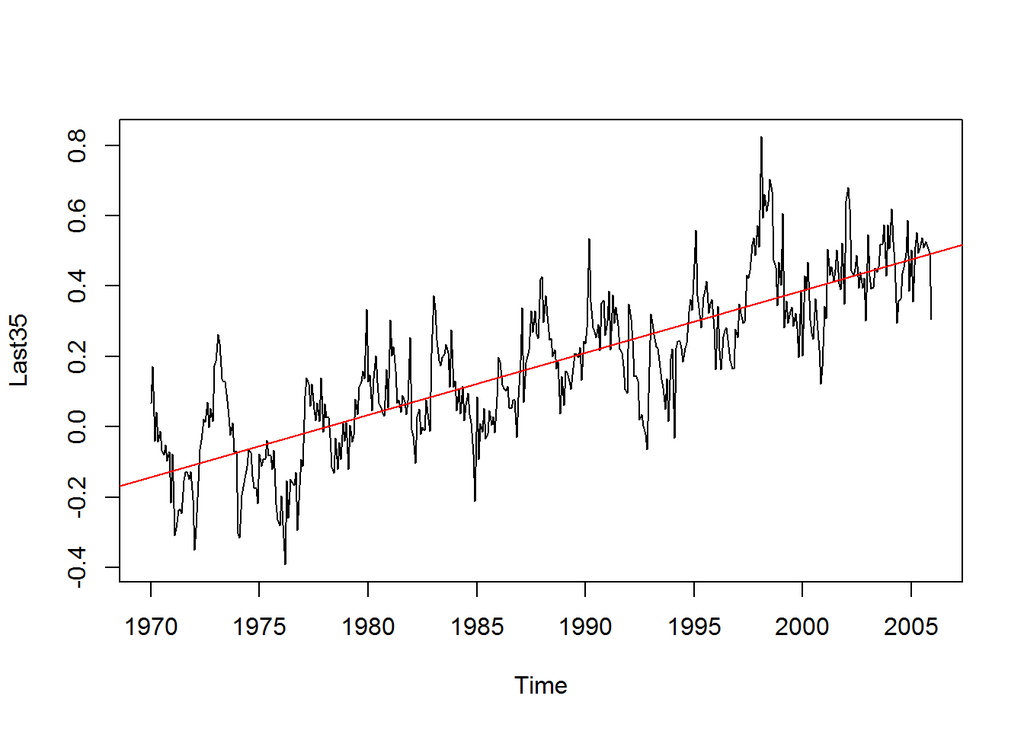

```r
plot(Last35)
  abline(fitAD,col=2)
```

```r
  confint(fitAD)
```

```
##                    2.5 %       97.5 %
## (Intercept) -37.21001248 -32.63080554
## Last35Yrs     0.01650228   0.01880572
```

### 3.1.2 Standard Errors incorrect

The confidence interval for the slope does not contain zero, which would provide statistical evidence of an increasing trend in global temperatures if the autocorrelation in the residuals is negligible. However, the residual series is positively autocorrelated at shorter lags:

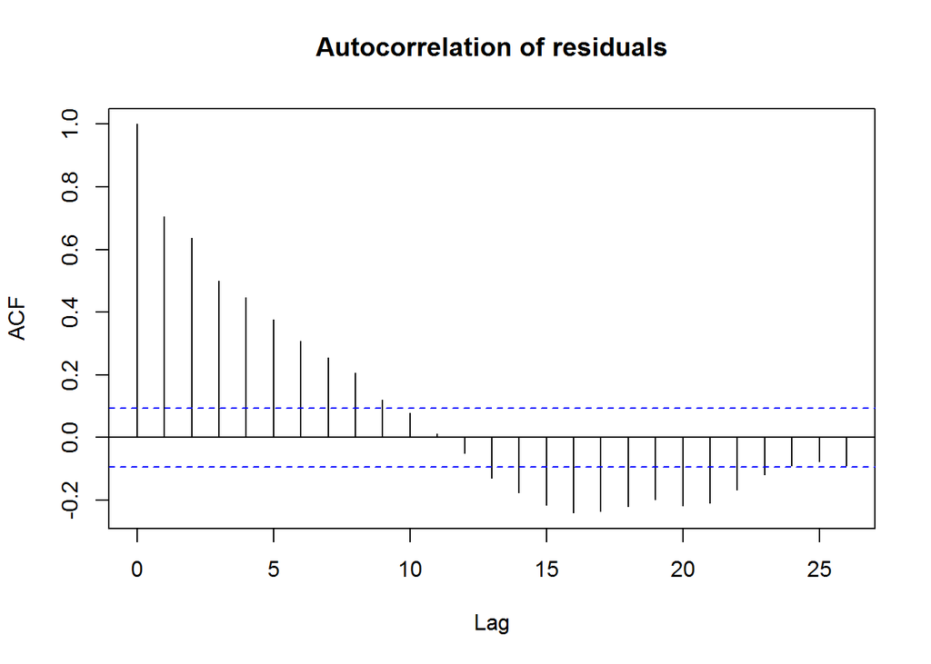

```r
acf(resid(fitAD),  main = "Autocorrelation of residuals")
```

, leading to an underestimate of the standard error and too narrow a confidence interval for the slope. Intuitively, the positive correlation between consecutive values reduces the effective record length because similar values will tend to occur together. The following section illustrates the reasoning behind this but may be omitted, without loss of continuity, by readers who do not require the mathematical details.

#### 3.1.2.1 Generalised least squares

For a positive serial correlation in the residual series, this implies that the standard errors of the estimated regression parameters are likely to be underestimated, and should therefore be corrected. A fitting procedure known as generalised least squares (GLS) can be used to provide better estimates of the standard errors of the regression parameters to account for the autocorrelation in the residual series. The procedure is essentially based on maximising the likelihood given the autocorrelation in the data and is implemented in R in the gls function (within the nlme library, which you will need to load).

```r
library(nlme)
x.gls <- gls(Last35 ~ Last35Yrs, cor = corAR1(0.7))
confint(x.gls)
```

```
##                    2.5 %       97.5 %
## (Intercept) -39.80571681 -28.49658850
## Last35Yrs     0.01442274   0.02011148
```

```r
#par(mar=c(7,3,1,1));
#pacf(fitAD$residuals,lag.max = 10)
```

### 3.1.3 stochastic model

The data exhibit an increasing trend after 1970, which may be due to the *greenhouse effect*. Sceptics may claim that the apparent increasing trend can be dismissed as a transient stochastic phenomenon. For their claim to be consistent with the time series data, it should be possible to model the trend without the use of deterministic functions. Consider the following AR model fitted to the mean annual temperature series:

```r
 Global.ar <- ar(Global.annual, method = "mle")
mean(aggregate(Global.ts, FUN = mean))
```

```
## [1] -0.1382628
```

```r
 Global.ar$ar
```

```
## [1] 0.58762026 0.01260254 0.11116731 0.26763656
```

```r
 options(digits=3)
 rbind(Global.ar$ar -2 * sqrt(diag(Global.ar$asy.var)),
       Global.ar$ar,
       Global.ar$ar +2 * sqrt(diag(Global.ar$asy.var)) )
```

```
##       [,1]    [,2]    [,3]  [,4]
## [1,] 0.449 -0.1559 -0.0574 0.129
## [2,] 0.588  0.0126  0.1112 0.268
## [3,] 0.726  0.1812  0.2797 0.406
```

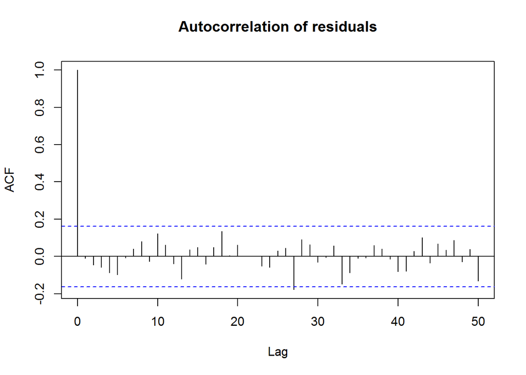

```r
acf(Global.ar$res[-(1:Global.ar$order)], lag = 50, main = "Autocorrelation of residuals")
```

The correlogram of the residuals has only one (marginally) significant value at lag 27, so the underlying residual series could be white noise. Thus the fitted AR(4) model provides a good fit to the data. As the AR model has no deterministic trend component, the trends in the data can be explained by serial correlation and random variation, implying that it is possible that these trends are stochastic (or could arise from a purely stochastic process). Again we emphasise that this does not imply that there is no underlying reason for the trends. If a valid scientific explanation is known, such as a link with the increased use of fossil fuels, then this information would clearly need to be included in any future forecasts of the series.

## 3.2 Logistic regression

Back to the Titanic data. How did the survival probability depend on age?

```r
fit = glm(Survived ~ Age, family = binomial, data = train)
pander(summary(fit)$coefficients)
```

|  | Estimate | Std. Error | z value | Pr(>\|z\|) |
| --- | --- | --- | --- | --- |
| **(Intercept)** | -0.05672 | 0.1736 | -0.3268 | 0.7438 |
| **Age** | -0.01096 | 0.00533 | -2.057 | 0.03969 |

**Give a precise interpretation of the slope**

### 3.2.1 Dummies/factors

```r
fit = glm(Survived ~ Pclass, family = binomial, data = train)
pander(summary(fit)$coefficients)
```

|  | Estimate | Std. Error | z value | Pr(>\|z\|) |
| --- | --- | --- | --- | --- |
| **(Intercept)** | 1.447 | 0.2074 | 6.975 | 3.063e-12 |
| **Pclass** | -0.8501 | 0.08715 | -9.755 | 1.755e-22 |

```r
fit = glm(Survived ~ factor(Pclass), family = binomial, data = train)
pander(summary(fit)$coefficients)
```

|  | Estimate | Std. Error | z value | Pr(>\|z\|) |
| --- | --- | --- | --- | --- |
| **(Intercept)** | 0.5306 | 0.1409 | 3.766 | 0.0001659 |
| **factor(Pclass)2** | -0.6394 | 0.2041 | -3.133 | 0.001731 |
| **factor(Pclass)3** | -1.67 | 0.1759 | -9.496 | 2.187e-21 |

```r
fit = glm(Survived ~ factor(Pclass) -1, family = binomial, data = train)
pander(summary(fit)$coefficients)
```

|  | Estimate | Std. Error | z value | Pr(>\|z\|) |
| --- | --- | --- | --- | --- |
| **factor(Pclass)1** | 0.5306 | 0.1409 | 3.766 | 0.0001659 |
| **factor(Pclass)2** | -0.1088 | 0.1477 | -0.7368 | 0.4612 |
| **factor(Pclass)3** | -1.14 | 0.1053 | -10.82 | 2.697e-27 |

## 3.3 multiple regression

```r
fit1=glm(Survived ~ Pclass + Sex + Age + Fare, data = train, family=binomial)
pander(summary(fit1)$coefficients)
```

|  | Estimate | Std. Error | z value | Pr(>\|z\|) |
| --- | --- | --- | --- | --- |
| **(Intercept)** | 4.988 | 0.5722 | 8.717 | 2.845e-18 |
| **Pclass** | -1.27 | 0.1586 | -8.005 | 1.198e-15 |
| **Sexmale** | -2.518 | 0.2079 | -12.12 | 8.787e-34 |
| **Age** | -0.03671 | 0.00768 | -4.78 | 1.754e-06 |
| **Fare** | 0.0005373 | 0.002182 | 0.2462 | 0.8055 |

```r
fit2=glm(Survived ~ Pclass + Sex + Age, data = train, family=binomial)
pander(summary(fit2)$coefficients)
```

|  | Estimate | Std. Error | z value | Pr(>\|z\|) |
| --- | --- | --- | --- | --- |
| **(Intercept)** | 5.056 | 0.5021 | 10.07 | 7.563e-24 |
| **Pclass** | -1.289 | 0.1393 | -9.253 | 2.186e-20 |
| **Sexmale** | -2.522 | 0.2073 | -12.17 | 4.626e-34 |
| **Age** | -0.03693 | 0.007628 | -4.841 | 1.289e-06 |

## 3.4 ANOVA

### 3.4.1 Comparison of nested models

See page 130 in the ISL book.

The anova() function performs a hypothesis test comparing the two models. The null hypothesis is that the two models fit the data equally well, and the alternative hypothesis is that the full model is superior.

```r
 fit1=lm(Survived ~ Pclass + Sex + Age + Fare, data = train)
 fit2=lm(Survived ~ Pclass + Sex + Age , data = train)

anova(fit1,fit2)
```

```
## Analysis of Variance Table
##
## Model 1: Survived ~ Pclass + Sex + Age + Fare
## Model 2: Survived ~ Pclass + Sex + Age
##   Res.Df RSS Df Sum of Sq    F Pr(>F)
## 1    709 105
## 2    710 105 -1  -0.00621 0.04   0.84
```

### 3.4.2 Differences in means

Are there significant differences in delays by airport in the flight data?

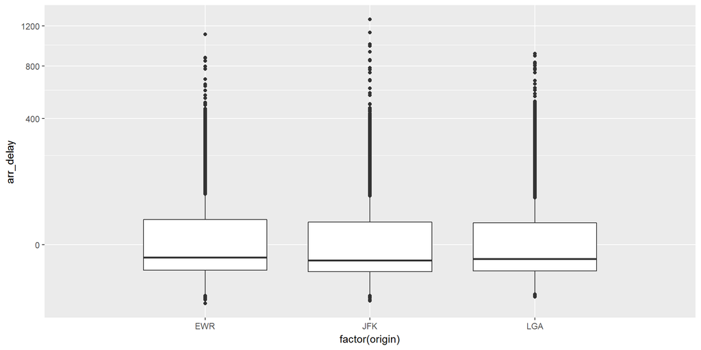

```r
if (baseR){
  boxplot(arr_delay ~ origin, data=flights)
  grid()
} else {
  p = ggplot(flights, aes( factor(origin),arr_delay))
  p + geom_boxplot() + coord_trans(y="sign_sqrt") #+ scale_y_sqrt()
}
```

Can we use ANOVA to determine its significance?

Yes, a linear model:

```r
summary(lm(arr_delay ~ factor(origin) -1, data = flights))
```

```
##
## Call:
## lm(formula = arr_delay ~ factor(origin) - 1, data = flights)
##
## Residuals:
##    Min     1Q Median     3Q    Max
##  -95.1  -23.8  -11.8    7.2 1266.4
##
## Coefficients:
##                   Estimate Std. Error t value Pr(>|t|)
## factor(origin)EWR    9.107      0.130    69.9   <2e-16 ***
## factor(origin)JFK    5.551      0.135    41.1   <2e-16 ***
## factor(origin)LGA    5.783      0.140    41.2   <2e-16 ***
## ---
## Signif. codes:  0 '***' 0.001 '**' 0.01 '*' 0.05 '.' 0.1 ' ' 1
##
## Residual standard error: 44.6 on 327343 degrees of freedom
##   (9430 observations deleted due to missingness)
## Multiple R-squared:  0.0247, Adjusted R-squared:  0.0246
## F-statistic: 2.76e+03 on 3 and 327343 DF,  p-value: <2e-16
```

```r
myAOV = aov(arr_delay ~ factor(origin) -1, data = flights)

summary(myAOV)
```

```
##                    Df   Sum Sq Mean Sq F value Pr(>F)
## factor(origin)      3 1.65e+07 5486345    2758 <2e-16 ***
## Residuals      327343 6.51e+08    1989
## ---
## Signif. codes:  0 '***' 0.001 '**' 0.01 '*' 0.05 '.' 0.1 ' ' 1
## 9430 observations deleted due to missingness
```

The ANOVA F-test answers the question whether there are significant differences in the K population means. However, it does not provide us with any information about how they differ. Therefore when you reject $H_0$ in ANOVA, additional analyses are required to determine what is driving the difference in means. The function `pairwise.t.test` computes the pairwise comparisons between group means with corrections for multiple testing.

```r
pairwise.t.test(flights$arr_delay, flights$origin, adjust="bonferroni")
```

```
##
##  Pairwise comparisons using t tests with pooled SD
##
## data:  flights$arr_delay and flights$origin
##
##     EWR    JFK
## JFK <2e-16 -
## LGA <2e-16 0.2
##
## P value adjustment method: holm
```

Another multiple comparisons procedure is Tukey???s method. The function `TukeyHSD()` creates a set of confidence intervals on the differences between means with the specified family-wise probability of coverage:

```r
TukeyHSD(myAOV)
```

```
##   Tukey multiple comparisons of means
##     95% family-wise confidence level
##
## Fit: aov(formula = arr_delay ~ factor(origin) - 1, data = flights)
##
## $`factor(origin)`
##           diff    lwr    upr p adj
## JFK-EWR -3.556 -3.995 -3.116 0.000
## LGA-EWR -3.324 -3.772 -2.875 0.000
## LGA-JFK  0.232 -0.224  0.688 0.458
```

## 3.5 Logistic Regression with the Stock Market Data

```r
library(ISLR)
names(Smarket)
```

```
##  [1] "Year"      "Lag1"      "Lag2"      "Lag3"      "Lag4"
##  [6] "Lag5"      "Volume"    "Today"     "Direction" "day"
```

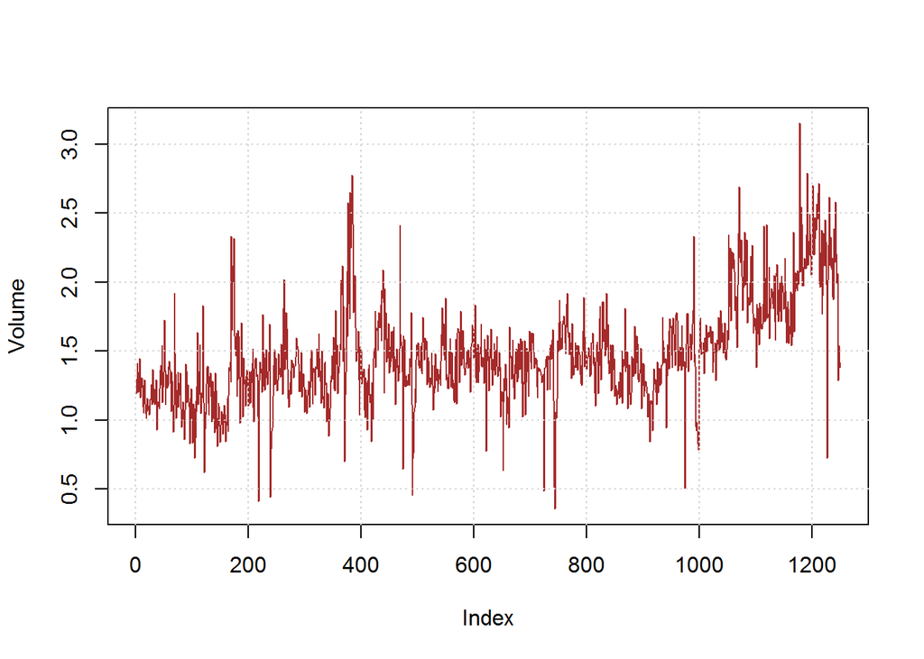

```r
#dim(Smarket)
#summary(Smarket)
#pairs(Smarket)
#cor(Smarket)
#cor(Smarket[,-9])
attach(Smarket)
plot(Volume, type="l", col = "brown");grid()
```

we will fit a logistic regression model in order to predict Direction using Lag1 through Lag5 and Volume.

But we need to be careful: the *training error rate* is often overly optimistic-it tends to underestimate the test error rate. In order to better assess the accuracy of the logistic regression model in this setting, we can fit the model using part of the data, and then examine how well it predicts the held out data. This will yield a more realistic error rate, in the sense that in practice we will be interested in our model’s performance not on the data that we used to fit the model, but rather on days in the future for which the market’s movements are unknown.

To implement this strategy, we will first create a vector corresponding to the observations from 2001 through 2004. We will then use this vector to create a held out data set of observations from 2005.

```r
train=(Year<2005)
Smarket.2005=Smarket[!train,]
dim(Smarket.2005)
```

```
## [1] 252  10
```

```r
Direction.2005=Direction[!train]
```

The object train is a vector of 1, 250 elements, corresponding to the observations in our data set. The elements of the vector that correspond to observations that occurred before 2005 are set to `TRUE`, whereas those that correspond to observations in 2005 are set to `FALSE`. The object train is a **Boolean** vector, since its elements are TRUE and `FALSE`.

We now fit a logistic regression model using only the subset of the observations that correspond to dates before 2005, using the subset argument. We then obtain predicted probabilities of the stock market going up for each of the days in our test set-that is, for the days in 2005.

```r
glm.fit=glm(Direction~Lag1+Lag2+Lag3+Lag4+Lag5+Volume,data=Smarket,family=binomial,subset=train)
glm.probs=predict(glm.fit,Smarket.2005,type="response")
```

Notice that we have trained and tested our model on two completely separate data sets: training was performed using only the dates before 2005, and testing was performed using only the dates in 2005. Finally, we compute the predictions for 2005 and compare them to the actual movements of the market over that time period.

```r
glm.pred=rep("Down",252)
glm.pred[glm.probs>.5]="Up"
table(glm.pred,Direction.2005)
```

```
##         Direction.2005
## glm.pred Down Up
##     Down   77 97
##     Up     34 44
```

```r
mean(glm.pred==Direction.2005)
```

```
## [1] 0.48
```

```r
mean(glm.pred!=Direction.2005)
```

```
## [1] 0.52
```

The != notation means not equal to, and so the last command computes the test set error rate. The results are rather disappointing: the test error rate is 52 %, which is worse than random guessing! Of course this result is not all that surprising, given that one would not generally expect to be able to use previous days’ returns to predict future market performance. (After all, if it were possible to do so, then the authors of this book would be out striking it rich rather than writing a statistics textbook.)

```r
glm.fit=glm(Direction~Lag1+Lag2,data=Smarket,family=binomial,subset=train)
glm.probs=predict(glm.fit,Smarket.2005,type="response")
glm.pred=rep("Down",252)
glm.pred[glm.probs>.5]="Up"
table(glm.pred,Direction.2005)
```

```
##         Direction.2005
## glm.pred Down  Up
##     Down   35  35
##     Up     76 106
```

```r
mean(glm.pred==Direction.2005)
```

```
## [1] 0.56
```

```r
106/(106+76)
```

```
## [1] 0.582
```

```r
predict(glm.fit,newdata=data.frame(Lag1=c(1.2,1.5),Lag2=c(1.1,-0.8)),type="response")
```

```
##     1     2
## 0.479 0.496
```

Now the results appear to be a little better: 56% of the daily movements have been correctly predicted. It is worth noting that in this case, a much simpler strategy of predicting that the market will increase every day will also be correct 56% of the time! Hence, in terms of overall error rate, the logistic regression method is no better than the naive approach. However, the confusion matrix shows that on days when logistic regression predicts an increase in the market, it has a 58% accuracy rate. This suggests a possible trading strategy of buying on days when the model predicts an increasing market, and avoiding trades on days when a decrease is predicted. Of course one would need to investigate more carefully whether this small improvement was real or just due to random chance.

# 4 Appendix

## 4.1 Leverage, Influence and Cook’s distance

## 4.2 Autocorrelation and the estimation of sample statistics

To illustrate the effect of autocorrelation in estimation, the sample mean will be used, as it is straightforward to analyse and is used in the calculation of other statistical properties. Suppose $x_t : t = 1, .., n$ is a time series of independent random variables with mean $E(x_t) = \mu$ and variance $Var(x_t) =\sigma^2$. Then it is well known in the study of random samples that the sample mean $\bar{x} = \sum_{t=1}^n{x_t}/n$ has mean $E(\bar{x}) = \mu$ and variance $Var(\bar{x}) =\sigma^2/n$

Now let $x_t : t = 1, .., n$ be a stationary time series with $E(x_t) = \mu$ and variance $Var(x_t) =\sigma^2$, and autocorrelation function $Cor(x_t, x_{t+k}) = \rho_k$. Then the variance of the sample mean is given by

$$Var(\bar{x}) =\frac{\sigma^2}{n} \left(1 + 2 \sum_{k=1}^{n-1}{(1-k/n) \rho_k} \right)$$

## 4.3 Sources

1. Analysis of temperature data leans heavily on “Introductory Time Series with R”, by Cowpertwait and Metcalfe.
2. Stock market regression is taken from “An Introduction to Statistical Learning”, by Gareth James, Daniela Witten, Trevor Hastie, Robert Tibshirani.